# Project: Investigate a Dataset - Brazilian Hospital data set

- Introduction
- Data Wrangling
- Exploratory Data Analysis
- Conclusions

## Introduction

### Dataset Description

> **The** dataset contains valiable information about a count of 100k medical appoinments that took place in Brazil, these information spins around a bold clear answer for each case, stating wether or not the patient managed to show up at the appointment on the pre-determined date.

We will be dealing with a data frame that consists of 14 columns, explained as follows:

- *PatientId* : Identification number crossponding to each patient.
- *AppointmentID* : Identification number crossponding to each appointment.
- *Gender*: The sex of the patient, wether male or female.
- *ScheduledDay* : The day when the patient called to set up their appointment.
- *AppointmentDay* : The actual day when the patient showed up.
- *Age* : The age of the patient.
- *Neighbourhood* : The location of each crossponding hospital for each case.
- *Scholarship* : Indicates whether or not the patient is enrolled in Brasilian welfare program Bolsa Familia.
- *Hypertension* : Indicates whether the patient suffers from high blood pressure or not.
- *Diabetes* : Indicates whether the patient suffers from diabetes or not
- *Alcoholism* : Indicates whether or not the patient suffers from health problem as a result from alcohol drinking.
- *Handicap* : Indicates on level from 0 to 4 if the patient is having any kind of disadvantage.
- *SMS_received* : whether or not the patient recieved a message or more with the appointment scheduled date.
- *No-show* : Indicates whether or not the patient managed to attend the appointment.

### Questions for Analysis

- 1. Is there a relation ship between the age of the patient and whether they showed up for the appointment or not?
- 2. Is there a relation ship between the gender of the patient and missing the appointment day?
- 3. Do patients enrolled in the Bolsa Familia are more or less encouraged to attend the appointment?

```python
# Importing neccessary libraries for our data analysis process.
import numpy as np
import pandas as pd
import matplotlib.pyplot as plt
import seaborn as srs
import time as time
%matplotlib inline
```

## Data Wrangling

> **In** this section of the report, we will load in the data, check for cleanliness, and then trim and cleanyour dataset for analysis.

### General Properties

> **In** this section, we will be loading and assessing our data sets:

```python
# Loading the dataset.
df = pd.read_csv('Database_No_show_appointments/noshowappointments-kagglev2-may-2016.csv')
df.head()
```

|  | PatientId | AppointmentID | Gender | ScheduledDay | AppointmentDay | Age | Neighbourhood | Scholarship | Hipertension | Diabetes | Alcoholism | Handcap | SMS_received | No-show |
| --- | --- | --- | --- | --- | --- | --- | --- | --- | --- | --- | --- | --- | --- | --- |
| 0 | 2.987250e+13 | 5642903 | F | 2016-04-29T18:38:08Z | 2016-04-29T00:00:00Z | 62 | JARDIM DA PENHA | 0 | 1 | 0 | 0 | 0 | 0 | No |
| 1 | 5.589978e+14 | 5642503 | M | 2016-04-29T16:08:27Z | 2016-04-29T00:00:00Z | 56 | JARDIM DA PENHA | 0 | 0 | 0 | 0 | 0 | 0 | No |
| 2 | 4.262962e+12 | 5642549 | F | 2016-04-29T16:19:04Z | 2016-04-29T00:00:00Z | 62 | MATA DA PRAIA | 0 | 0 | 0 | 0 | 0 | 0 | No |
| 3 | 8.679512e+11 | 5642828 | F | 2016-04-29T17:29:31Z | 2016-04-29T00:00:00Z | 8 | PONTAL DE CAMBURI | 0 | 0 | 0 | 0 | 0 | 0 | No |
| 4 | 8.841186e+12 | 5642494 | F | 2016-04-29T16:07:23Z | 2016-04-29T00:00:00Z | 56 | JARDIM DA PENHA | 0 | 1 | 1 | 0 | 0 | 0 | No |

```python
df.shape
```

```
(110527, 14)
```

```python
# Summary statistics about our dataset
df.describe()
```

|  | PatientId | AppointmentID | Age | Scholarship | Hipertension | Diabetes | Alcoholism | Handcap | SMS_received |
| --- | --- | --- | --- | --- | --- | --- | --- | --- | --- |
| count | 1.105270e+05 | 1.105270e+05 | 110527.000000 | 110527.000000 | 110527.000000 | 110527.000000 | 110527.000000 | 110527.000000 | 110527.000000 |
| mean | 1.474963e+14 | 5.675305e+06 | 37.088874 | 0.098266 | 0.197246 | 0.071865 | 0.030400 | 0.022248 | 0.321026 |
| std | 2.560949e+14 | 7.129575e+04 | 23.110205 | 0.297675 | 0.397921 | 0.258265 | 0.171686 | 0.161543 | 0.466873 |
| min | 3.921784e+04 | 5.030230e+06 | -1.000000 | 0.000000 | 0.000000 | 0.000000 | 0.000000 | 0.000000 | 0.000000 |
| 25% | 4.172614e+12 | 5.640286e+06 | 18.000000 | 0.000000 | 0.000000 | 0.000000 | 0.000000 | 0.000000 | 0.000000 |
| 50% | 3.173184e+13 | 5.680573e+06 | 37.000000 | 0.000000 | 0.000000 | 0.000000 | 0.000000 | 0.000000 | 0.000000 |
| 75% | 9.439172e+13 | 5.725524e+06 | 55.000000 | 0.000000 | 0.000000 | 0.000000 | 0.000000 | 0.000000 | 1.000000 |
| max | 9.999816e+14 | 5.790484e+06 | 115.000000 | 1.000000 | 1.000000 | 1.000000 | 1.000000 | 4.000000 | 1.000000 |

```python
# Checking the structure of the data for any missing values & making sure it is in appropriate types.
df.info()
```

```
<class 'pandas.core.frame.DataFrame'>
RangeIndex: 110527 entries, 0 to 110526
Data columns (total 14 columns):
PatientId         110527 non-null float64
AppointmentID     110527 non-null int64
Gender            110527 non-null object
ScheduledDay      110527 non-null object
AppointmentDay    110527 non-null object
Age               110527 non-null int64
Neighbourhood     110527 non-null object
Scholarship       110527 non-null int64
Hipertension      110527 non-null int64
Diabetes          110527 non-null int64
Alcoholism        110527 non-null int64
Handcap           110527 non-null int64
SMS_received      110527 non-null int64
No-show           110527 non-null object
dtypes: float64(1), int64(8), object(5)
memory usage: 11.8+ MB
```

> **As** we can see, our dataset consists of 110527 different cases, for each we have data for the pre-mentioned columns.

We had a look at the summary statistics of each feature in our dataset. Apparently, we have no missing data, but the data types need some adjusting. There is also a row where the age is -1 , which is unlogical, so we are going to drop that row.

### Data Cleaning

> **Here** we will be fixing some detected issues with our dataset:

> 1- **We** have noticed that both columns *PatientId* & *AppointmentID* are overlapping as they are both unique numbers refering for each case. For simplicty, we are gonna remove one of them and keep the other, It'll help us refer to certain case.

> 2- **Some** data types needs fixing:
- *ScheduledDay* data type is string and needs to be in datetime format.
- *AppointmentDay* data type is string and needs to be in datetime format.

> 3- **Column** names needs a little adjusting to be all in the same format.

> 4- **We** will also be checking for any duplicate rows in our dataset.

> 5- **Drop** wrong data row.

> 6- **Finally**, *No_show* column name is a little bit confusing, we will change it's name to *show* and we will be converting the values of the *No-show* column to 0 & 1 instead of 'No' & 'Yes' & changing its type to int.

```python
# Droping undesired data column.
df.drop('PatientId',axis=1,inplace=True)
```

```python
#Converting data types of PateintId , SheduledDay, AppointmentDay
df['ScheduledDay'] = pd.to_datetime(df['ScheduledDay'])
df['AppointmentDay'] = pd.to_datetime(df['AppointmentDay'])
```

```python
# Converting column names to lower case & uniting seperators.
df.rename(columns=lambda x: x.strip().lower().replace('-','_'), inplace=True)
```

```python
# Fixing dictation error with column names: 'hipertension' & 'handcap'
df.rename(columns = {'hipertension': 'hypertension','handcap':'handicap'},inplace=True)
```

```python
# Checking for duplicates in our dataset
sum(df.duplicated())
```

```
0
```

```python
# Accessing the row that contains wrong data.
df['age'][df['age']<0]
```

```
99832   -1
Name: age, dtype: int64
```

```python
# Droping the row no. 99832 that contains wrong data.
df.drop(99832,axis=0,inplace=True)
```

```python
#Checking for changes fixed.
df['age'][df['age']<0]
```

```
Series([], Name: age, dtype: int64)
```

```python
#Renaming the no_show column to 'show'.
df.rename(columns = {'no_show' : 'show'},inplace=True)
df['show'] = df['show'].replace('No',1) # 1 indicates that the patient did show up.
df['show'] = df['show'].replace('Yes',0) # 0 indicates that the patient didn't show up.
df['show'].unique()
```

```
array([1, 0])
```

```python
#Checking for changes fixed.
df.info()
```

```
<class 'pandas.core.frame.DataFrame'>
Int64Index: 110526 entries, 0 to 110526
Data columns (total 13 columns):
appointmentid     110526 non-null int64
gender            110526 non-null object
scheduledday      110526 non-null datetime64[ns]
appointmentday    110526 non-null datetime64[ns]
age               110526 non-null int64
neighbourhood     110526 non-null object
scholarship       110526 non-null int64
hypertension      110526 non-null int64
diabetes          110526 non-null int64
alcoholism        110526 non-null int64
handicap          110526 non-null int64
sms_received      110526 non-null int64
show              110526 non-null int64
dtypes: datetime64[ns](2), int64(9), object(2)
memory usage: 11.8+ MB
```

> **Now**, that we have checked our data structure, made sure there is no duplicated rows as well as there is no missing data & edited column names.

We have our data fixed to be able to perform proper calculations.

> Our data now consists of 110526 rows & for each a count of 13 features.

We can now start explorig our dataset to find patterns & augmenting our data to maximize the potential of this analytical study.

## Exploratory Data Analysis

### General exploration

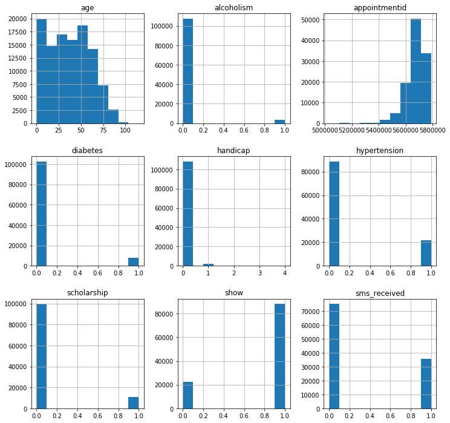

```python
# Ploting histograms to see the frequency of each unique value in each feature.
df.hist(figsize=(12,12));
```

```python
# Creating a function for ploting bar charts.
def plot_bar_chart(df_to_plot,label_list,colors,trans,title,xlabel,ylabel):
    ''' This function is used to plot bar charts on equally distrubuted x-coordinates
    for multiple data arrays, with all the needed features included: tick labels,colors of bars, and transparency of bars.'''
    i = 0
    while i < len(df_to_plot):
        plt.bar([1,2],df_to_plot[i],tick_label=label_list,color=colors[i],alpha=trans);
        i += 1
    plt.title(title,fontsize=14);
    plt.xlabel(xlabel,fontsize=12);
    plt.ylabel(ylabel,fontsize=12);
    plt.legend();
    plt.show();
```